# Fuel Prices Across Auckland

## Introduction

This report is a analysis of fuel prices across different fuel stations in Auckland. Since March, we have been recording the prices of fuel and seeing which fuel station will save the consumer money for fueling.

## Prices for Unleaded 91 by Month

In the recorded survey, for the month of **March**, the prices for Unleaded 91 were between **$3.30 and $3.50** dollars and the median price was around **$3.41**.

The prices for **May**, were between **$3.30 and $3.40** and the median price was around **$3.31**.

From comparing the two month period in the survey, the prices seemed to have had a drop of around **10 cents per litre**.

There was a noticeable outlier in **May** with a price of **$3.11** which is unusually out of the range.

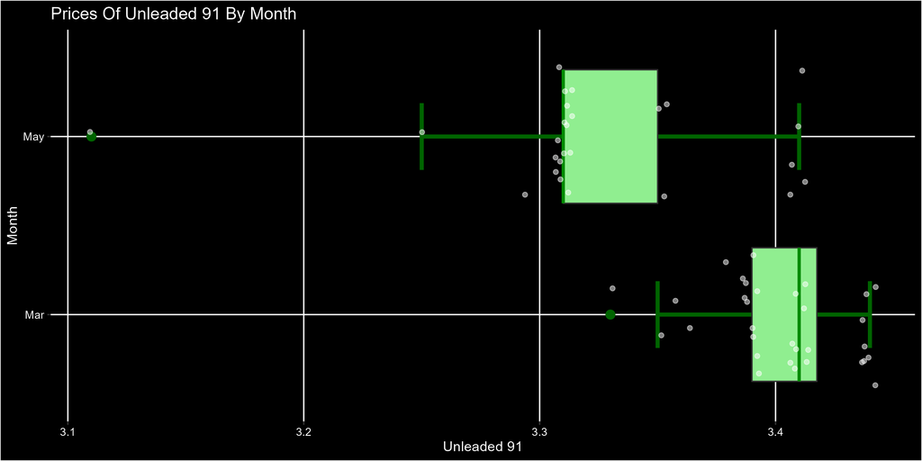

A graph representing the prices for Unleaded 91 by each month recorded

## Prices for Premium 95 for Mobil

For the Premium 95 graph, the prices are taken from the Mobil stations recorded in the survey.

The highest price for Premium 95 for Mobil stations was **$3.66** on the **31st of March** and the lowest price was **$3.53** on the **7th of May**.

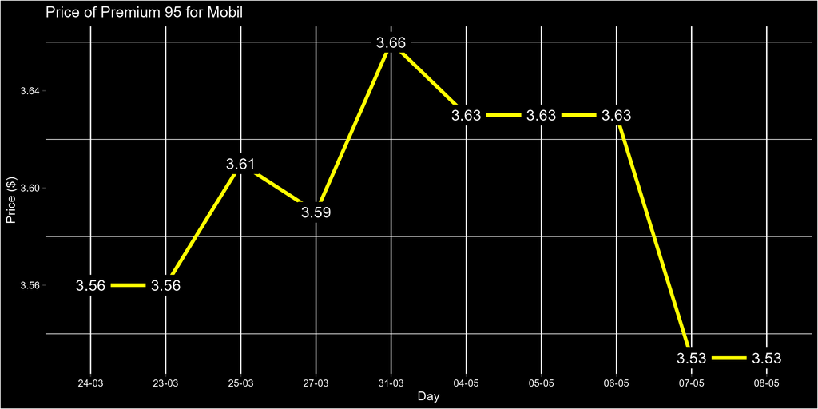

A graph representing the prices for Premium 95 for Mobil fuel stations

## Total cars for each recorded fuel brand

In the survey, we also recorded the number of cars that were present at the time.

The brand with the highest total cars present was **BP** with **91** total cars present that was recorded on this survey and the brand with the least total cars present was **U-GO** with **7** total cars.

*This may not however truly reflect the true amount of visits for each brand as one brand might have been recorded more than the others.*

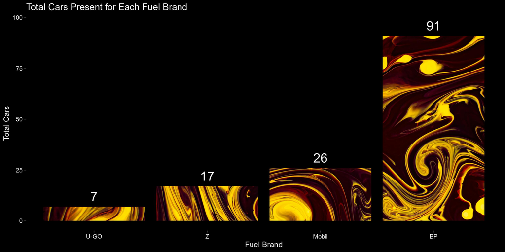